# HS_614_FINAL_EDA

Shuhao Zhou

5/12/2022

```r
library(dplyr)
```

```r
library(corrplot)
library(ggplot2)
```

Create a dataframe for EDA (pretty much the same process with the data processing part but not converting the categorical variables to dummy variables)

```r
df_diabetes<-read.csv('C:/USFCA/HS 614/Final Project/diabetic_data.csv')

#Drop the following variables:
#encounter_id (irrelevant)
#patient_nbr (irrelevant)
#weight(too many missing)
#payer_code (too many missing)
df_diabetes <- subset(df_diabetes,select=-c(encounter_id,patient_nbr,weight,payer_code))

#Convert all the characters (other than diag_1, diag_2 and diag_3, which will be processed later) into factors
for (i in 1:ncol(df_diabetes)){
  if(is.character(df_diabetes[,i])&colnames(df_diabetes)[i]!='diag_1'&colnames(df_diabetes)[i]!='diag_2'&colnames(df_diabetes)[i]!='diag_3'){
    df_diabetes[,i]=factor(df_diabetes[,i])}
}

#Convert admission_type_id,discharge_disposition_id,admission_source_id into factors
df_diabetes$admission_type_id<-factor(df_diabetes$admission_type_id)
df_diabetes$admission_source_id<-factor(df_diabetes$admission_source_id)
df_diabetes$discharge_disposition_id<-factor(df_diabetes$discharge_disposition_id)

#Remove rows without information for the key variables
df_diabetes<-df_diabetes[df_diabetes$race!='?'&df_diabetes$gender!='Unknown/Invalid'&df_diabetes$medical_specialty!='?',]

df_diabetes$race <- factor(as.character(df_diabetes$race))
df_diabetes$gender <- factor(as.character(df_diabetes$gender))
df_diabetes$medical_specialty <- factor(as.character(df_diabetes$medical_specialty))

#Remove variables where almost all the cases assigned with the same label
df_diabetes<-subset(df_diabetes,select=-c(chlorpropamide,acetohexamide,tolbutamide,acarbose,miglitol,troglitazone,tolazamide,examide,citoglipton,glipizide.metformin,glimepiride.pioglitazone,metformin.rosiglitazone,metformin.pioglitazone))

#Re-categorize some variables to make sure there’re decent number of observations under each label

df_diabetes$admission_type<-case_when(df_diabetes$admission_type_id==1~'emergency',
                                     df_diabetes$admission_type_id==2~'urgent',
                                     df_diabetes$admission_type_id==3~'elective')
df_diabetes$discharge_disposition<-case_when(df_diabetes$discharge_disposition_id==1~'Home',
!(df_diabetes$discharge_disposition_id %in% c(1,18,25,2))~'Others')

df_diabetes$admission_source<-case_when(df_diabetes$admission_source_id==7~'emergency_room',
                                       df_diabetes$admission_source_id %in% c(1,2)~'referral_from_physician_or_clinic',
                                       !(df_diabetes$admission_source_id %in% c(1,2,7,9,15,16,19,20))~'Others')

df_diabetes$admission_type<-factor(df_diabetes$admission_type)
df_diabetes$discharge_disposition<-factor(df_diabetes$discharge_disposition)
df_diabetes$admission_source<-factor(df_diabetes$admission_source)

df_diabetes$specialty_sm <- ifelse(df_diabetes$medical_specialty %in% c('InternalMedicine','Emergency/Trauma','Family/GeneralPractice','Cardiology','Surgery-General'),as.character(df_diabetes$medical_specialty),'Others')
df_diabetes$specialty_sm <- factor(df_diabetes$specialty_sm)

df_diabetes$repaglinide_status<-ifelse(df_diabetes$repaglinide %in% c('Down','Up'),'Change',as.character(df_diabetes$repaglinide))
df_diabetes$nateglinide_status<-ifelse(df_diabetes$nateglinide=='No','No','Taken')
df_diabetes$pioglitazone_status<-ifelse(df_diabetes$pioglitazone %in% c('Down','Up'),'Change',as.character(df_diabetes$pioglitazone))
df_diabetes$rosiglitazone_status<-ifelse(df_diabetes$rosiglitazone %in% c('Down','Up'),'Change',as.character(df_diabetes$rosiglitazone))
df_diabetes$glyburide.metformin_status<-ifelse(df_diabetes$glyburide.metformin=='No','No','Taken')

df_diabetes$repaglinide_status<-factor(df_diabetes$repaglinide_status)
df_diabetes$nateglinide_status<-factor(df_diabetes$nateglinide_status)
df_diabetes$pioglitazone_status<-factor(df_diabetes$pioglitazone_status)
df_diabetes$rosiglitazone_status<-factor(df_diabetes$rosiglitazone_status)
df_diabetes$glyburide.metformin_status<-factor(df_diabetes$glyburide.metformin_status)

df_diabetes$readmitted_binary<-ifelse(df_diabetes$readmitted=='<30','Yes','No')
df_diabetes$readmitted_binary<-factor(df_diabetes$readmitted_binary)

df_diabetes <- na.omit(df_diabetes)
```

Add dummy variables for diagnosis

```r
df_diabetes_diag=subset(df_diabetes,select=c(diag_1,diag_2,diag_3))

df_diabetes_diag$diag_circ <- 'No'
df_diabetes_diag$diag_resp <- 'No'
df_diabetes_diag$diag_dig <- 'No'
df_diabetes_diag$diag_diab <- 'No'
df_diabetes_diag$diag_inj <- 'No'
df_diabetes_diag$diag_musc <-'No'
df_diabetes_diag$diag_geni <- 'No'
df_diabetes_diag$diag_neop <-'No'
df_diabetes_diag$diag_other <- 'No'

df_diabetes_diag$diag_circ[(as.character( df_diabetes_diag$diag_1) >= "390" & as.character( df_diabetes_diag$diag_1) <= "459" |  as.character( df_diabetes_diag$diag_1 ) == "785")
                   | (as.character( df_diabetes_diag$diag_2) >= "390" & as.character( df_diabetes_diag$diag_2) <= "459" |  as.character( df_diabetes_diag$diag_2 ) == "785")
                   | (as.character( df_diabetes_diag$diag_3) >= "390" & as.character( df_diabetes_diag$diag_3) <= "459" |  as.character( df_diabetes_diag$diag_3 ) == "785")] <- 'Yes'

#creating diagnosis varible for Diabetes mellitus codes: 250.xx

df_diabetes_diag$diag_diab[(as.character(df_diabetes_diag$diag_1) > "249" & as.character(df_diabetes_diag$diag_1) < "251")
                   | (as.character(df_diabetes_diag$diag_2) > "249" & as.character(df_diabetes_diag$diag_2) < "251")
                   | (as.character(df_diabetes_diag$diag_3) > "249" & as.character(df_diabetes_diag$diag_3) < "251")] <- 'Yes'

#creating diagnosis varible for Respiratory codes: 460-519, 786

df_diabetes_diag$diag_resp[(as.character( df_diabetes_diag$diag_1) >= "460" & as.character( df_diabetes_diag$diag_1) <= "519" |  as.character( df_diabetes_diag$diag_1 ) == "786")
                   | (as.character( df_diabetes_diag$diag_2) >= "460" & as.character( df_diabetes_diag$diag_2) <= "519" |  as.character( df_diabetes_diag$diag_2 ) == "786")
                   | (as.character( df_diabetes_diag$diag_3) >= "460" & as.character( df_diabetes_diag$diag_3) <= "519" |  as.character( df_diabetes_diag$diag_3 ) == "786")] <- 'Yes'

#creating diagnosis varible for Digestive codes: 520-579, 787

df_diabetes_diag$diag_dig[(as.character( df_diabetes_diag$diag_1) >= "520" & as.character( df_diabetes_diag$diag_1) <= "579" |  as.character( df_diabetes_diag$diag_1 ) == "787")
                  | (as.character( df_diabetes_diag$diag_2) >= "520" & as.character( df_diabetes_diag$diag_2) <= "579" |  as.character( df_diabetes_diag$diag_2 ) == "787")
                  | (as.character( df_diabetes_diag$diag_3) >= "520" & as.character( df_diabetes_diag$diag_3) <= "579" |  as.character( df_diabetes_diag$diag_3 ) == "787")] <- 'Yes'

#creating diagnosis varible for Injury codes: 800-999

df_diabetes_diag$diag_inj[(as.character( df_diabetes_diag$diag_1) >= "800" & as.character( df_diabetes_diag$diag_1) <= "999")
                  | (as.character( df_diabetes_diag$diag_2) >= "800" & as.character( df_diabetes_diag$diag_2) <= "999")
                  | (as.character( df_diabetes_diag$diag_3) >= "800" & as.character( df_diabetes_diag$diag_3) <= "999")] <- 'Yes'

#creating diagnosis varible for Musculoskeletal codes: 710-739

df_diabetes_diag$diag_musc[(as.character( df_diabetes_diag$diag_1) >= "710" & as.character( df_diabetes_diag$diag_1) <= "739")
                   | (as.character( df_diabetes_diag$diag_2) >= "710" & as.character( df_diabetes_diag$diag_2) <= "739")
                   | (as.character( df_diabetes_diag$diag_3) >= "710" & as.character( df_diabetes_diag$diag_3) <= "739")] <- 'Yes'

#creating diagnosis varible for Genitourinary codes: 580-629, 788

df_diabetes_diag$diag_geni[(as.character( df_diabetes_diag$diag_1) >= "580" & as.character( df_diabetes_diag$diag_1) <= "629" |  as.character( df_diabetes_diag$diag_1 ) == "788")
                   | (as.character( df_diabetes_diag$diag_2) >= "580" & as.character( df_diabetes_diag$diag_2) <= "629" |  as.character( df_diabetes_diag$diag_2 ) == "788")
                   | (as.character( df_diabetes_diag$diag_3) >= "580" & as.character( df_diabetes_diag$diag_3) <= "629" |  as.character( df_diabetes_diag$diag_3 ) == "788")] <- 'Yes'

#creating diagnosis varible for Neoplasms codes: 140-239

df_diabetes_diag$diag_neop[(as.character( df_diabetes_diag$diag_1) >= "140" & as.character( df_diabetes_diag$diag_1) <= "239")
                   | (as.character( df_diabetes_diag$diag_2) >= "140" & as.character( df_diabetes_diag$diag_2) <= "239")
                   | (as.character( df_diabetes_diag$diag_3) >= "140" & as.character( df_diabetes_diag$diag_3) <= "239")] <- 'Yes'


df_diabetes_diag$diag_other[(as.character( df_diabetes_diag$diag_1) == "780") | (as.character( df_diabetes_diag$diag_1) == "781")
                    | (as.character( df_diabetes_diag$diag_1) == "784") | (as.character( df_diabetes_diag$diag_1) >= "790" & as.character( df_diabetes_diag$diag_1) <= "799")
                    | (as.character( df_diabetes_diag$diag_1) >= "240" & as.character( df_diabetes_diag$diag_1) <= "249") | (as.character( df_diabetes_diag$diag_1) >= "251" & as.character( df_diabetes_diag$diag_1) <= "279")
                    | (as.character( df_diabetes_diag$diag_1) >= "680" & as.character( df_diabetes_diag$diag_1) <= "709") | (as.character( df_diabetes_diag$diag_1) == "782")
                    | (as.character( df_diabetes_diag$diag_1) >= "001" & as.character( df_diabetes_diag$diag_1) <= "139") | (as.character( df_diabetes_diag$diag_1) >= "290" & as.character( df_diabetes_diag$diag_1) <= "319")
                    | (as.character( df_diabetes_diag$diag_1) >= "280" & as.character( df_diabetes_diag$diag_1) <= "289") | (as.character( df_diabetes_diag$diag_1) >= "320" & as.character( df_diabetes_diag$diag_1) <= "359")
                    | (as.character( df_diabetes_diag$diag_1) >= "630" & as.character( df_diabetes_diag$diag_1) <= "679") | (as.character( df_diabetes_diag$diag_1) >= "360" & as.character( df_diabetes_diag$diag_1) <= "389")
                    | (as.character( df_diabetes_diag$diag_1) >= "740" & as.character( df_diabetes_diag$diag_1) <= "759")
                    | (startsWith(as.character( df_diabetes_diag$diag_1), 'E'))
                    | (startsWith(as.character( df_diabetes_diag$diag_1), 'V'))
                    | (as.character( df_diabetes_diag$diag_2) == "780") | (as.character( df_diabetes_diag$diag_2) == "781")
                    | (as.character( df_diabetes_diag$diag_2) == "784") | (as.character( df_diabetes_diag$diag_2) >= "790" & as.character( df_diabetes_diag$diag_2) <= "799")
                    | (as.character( df_diabetes_diag$diag_2) >= "240" & as.character( df_diabetes_diag$diag_2) <= "249") | (as.character( df_diabetes_diag$diag_2) >= "251" & as.character( df_diabetes_diag$diag_2) <= "279")
                    | (as.character( df_diabetes_diag$diag_2) >= "680" & as.character( df_diabetes_diag$diag_2) <= "709") | (as.character( df_diabetes_diag$diag_2) == "782")
                    | (as.character( df_diabetes_diag$diag_2) >= "001" & as.character( df_diabetes_diag$diag_2) <= "139") | (as.character( df_diabetes_diag$diag_2) >= "290" & as.character( df_diabetes_diag$diag_2) <= "319")
                    | (as.character( df_diabetes_diag$diag_2) >= "280" & as.character( df_diabetes_diag$diag_2) <= "289") | (as.character( df_diabetes_diag$diag_2) >= "320" & as.character( df_diabetes_diag$diag_2) <= "359")
                    | (as.character( df_diabetes_diag$diag_2) >= "630" & as.character( df_diabetes_diag$diag_2) <= "679") | (as.character( df_diabetes_diag$diag_2) >= "360" & as.character( df_diabetes_diag$diag_2) <= "389")
                    | (as.character( df_diabetes_diag$diag_2) >= "740" & as.character( df_diabetes_diag$diag_2) <= "759")
                    | (startsWith(as.character( df_diabetes_diag$diag_2), 'E'))
                    | (startsWith(as.character( df_diabetes_diag$diag_2), 'V'))
                    | (as.character( df_diabetes_diag$diag_3) == "780") | (as.character( df_diabetes_diag$diag_3) == "781")
                    | (as.character( df_diabetes_diag$diag_3) == "784") | (as.character( df_diabetes_diag$diag_3) >= "790" & as.character( df_diabetes_diag$diag_3) <= "799")
                    | (as.character( df_diabetes_diag$diag_3) >= "240" & as.character( df_diabetes_diag$diag_3) <= "249") | (as.character( df_diabetes_diag$diag_3) >= "251" & as.character( df_diabetes_diag$diag_3) <= "279")
                    | (as.character( df_diabetes_diag$diag_3) >= "680" & as.character( df_diabetes_diag$diag_3) <= "709") | (as.character( df_diabetes_diag$diag_3) == "782")
                    | (as.character( df_diabetes_diag$diag_3) >= "001" & as.character( df_diabetes_diag$diag_3) <= "139") | (as.character( df_diabetes_diag$diag_3) >= "290" & as.character( df_diabetes_diag$diag_3) <= "319")
                    | (as.character( df_diabetes_diag$diag_3) >= "280" & as.character( df_diabetes_diag$diag_3) <= "289") | (as.character( df_diabetes_diag$diag_3) >= "320" & as.character( df_diabetes_diag$diag_3) <= "359")
                    | (as.character( df_diabetes_diag$diag_3) >= "630" & as.character( df_diabetes_diag$diag_3) <= "679") | (as.character( df_diabetes_diag$diag_3) >= "360" & as.character( df_diabetes_diag$diag_3) <= "389")
                    | (as.character( df_diabetes_diag$diag_3) >= "740" & as.character( df_diabetes_diag$diag_3) <= "759")
                    | (startsWith(as.character(df_diabetes_diag$diag_3), 'E'))
                    | (startsWith(as.character(df_diabetes_diag$diag_3), 'V'))] <- 'Yes'
```

```r
df_diabetes_diag <- subset(df_diabetes_diag,select=-c(diag_1,diag_2,diag_3))
for(i in 1:ncol(df_diabetes_diag)){
  if(is.character(df_diabetes_diag[,i])){
    df_diabetes_diag[,i] <- as.factor(df_diabetes_diag[,i])
  }
}
df_diabetes <- cbind(df_diabetes,df_diabetes_diag)
```

Drop unnecessary columns in the original dataframe

```r
df_diabetes <- subset(df_diabetes,select=-c(admission_type_id,discharge_disposition_id,admission_source_id,repaglinide,nateglinide,pioglitazone,rosiglitazone,glyburide.metformin,readmitted,medical_specialty,diag_1,diag_2,diag_3))
```

*EDA*  
Compute basic stats for all the variables

```r
summary(df_diabetes)
```

```
##               race          gender           age        time_in_hospital
##  AfricanAmerican: 9837   Female:23389   [70-80):10637   Min.   : 1.000
##  Asian          :  382   Male  :19544   [60-70): 9432   1st Qu.: 2.000
##  Caucasian      :31148                  [50-60): 7478   Median : 4.000
##  Hispanic       :  872                  [80-90): 6827   Mean   : 4.399
##  Other          :  694                  [40-50): 4334   3rd Qu.: 6.000
##                                         [30-40): 1738   Max.   :14.000
##                                         (Other): 2487
##  num_lab_procedures num_procedures  num_medications number_outpatient
##  Min.   :  1.00     Min.   :0.000   Min.   : 1.00   Min.   : 0.0000
##  1st Qu.: 33.00     1st Qu.:0.000   1st Qu.:10.00   1st Qu.: 0.0000
##  Median : 44.00     Median :1.000   Median :14.00   Median : 0.0000
##  Mean   : 43.03     Mean   :1.441   Mean   :15.73   Mean   : 0.2328
##  3rd Qu.: 56.00     3rd Qu.:2.000   3rd Qu.:20.00   3rd Qu.: 0.0000
##  Max.   :132.00     Max.   :6.000   Max.   :81.00   Max.   :38.0000
##
##  number_emergency  number_inpatient  number_diagnoses max_glu_serum
##  Min.   : 0.0000   Min.   : 0.0000   Min.   : 1.000   >200:   81
##  1st Qu.: 0.0000   1st Qu.: 0.0000   1st Qu.: 5.000   >300:   49
##  Median : 0.0000   Median : 0.0000   Median : 8.000   None:42571
##  Mean   : 0.2175   Mean   : 0.6443   Mean   : 7.198   Norm:  232
##  3rd Qu.: 0.0000   3rd Qu.: 1.0000   3rd Qu.: 9.000
##  Max.   :76.0000   Max.   :15.0000   Max.   :16.000
##
##  A1Cresult     metformin     glimepiride     glipizide      glyburide
##  >7  : 1766   Down  :  222   Down  :  106   Down  :  219   Down  :  192
##  >8  : 3945   No    :34457   No    :40207   No    :37335   No    :38958
##  None:35264   Steady: 7770   Steady: 2433   Steady: 5031   Steady: 3495
##  Norm: 1958   Up    :  484   Up    :  187   Up    :  348   Up    :  288
##
##
##
##    insulin      change     diabetesMed   admission_type  discharge_disposition
##  Down  : 5669   Ch:20582   No : 9096   elective :11436   Home  :29104
##  No    :18678   No:22351   Yes:33837   emergency:19421   Others:13829
##  Steady:13532                          urgent   :12076
##  Up    : 5054
##
##
##
```

[output cut: 25 more lines]

```
##  No :37105   No :25858   No :38717   No :39344   No :36430   No :40213
##  Yes: 5828   Yes:17075   Yes: 4216   Yes: 3589   Yes: 6503   Yes: 2720
##
##
##
##
##
##  diag_other
##  No :20570
##  Yes:22363
##
##
##
##
##
```

Plot histograms for all the numeric variables. It can be seen from the charts that most of these variables have highly varying magnitudes thus need to be scaled before performing machine learning later.

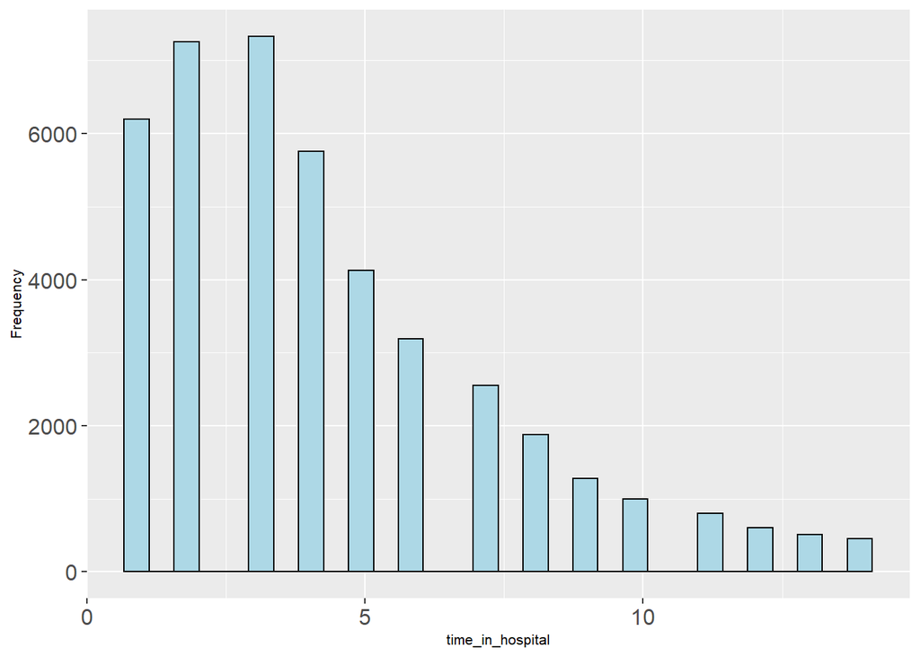

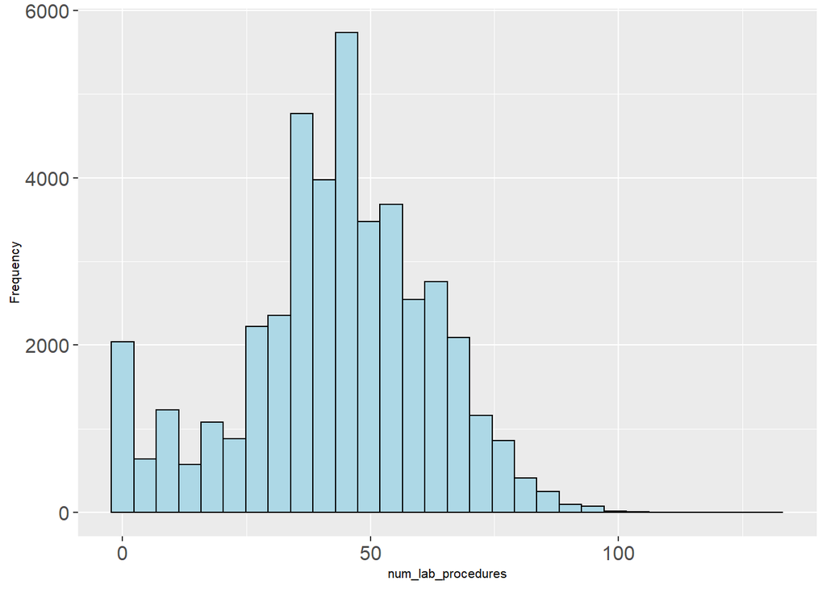

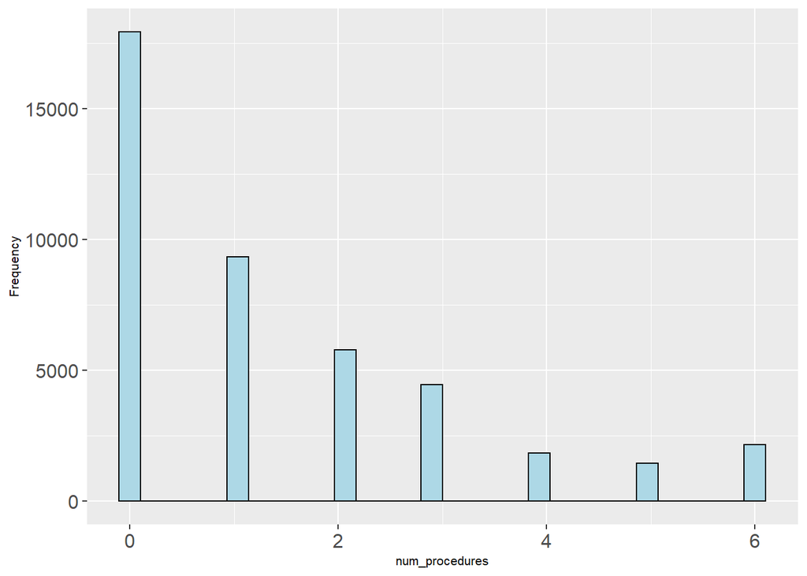

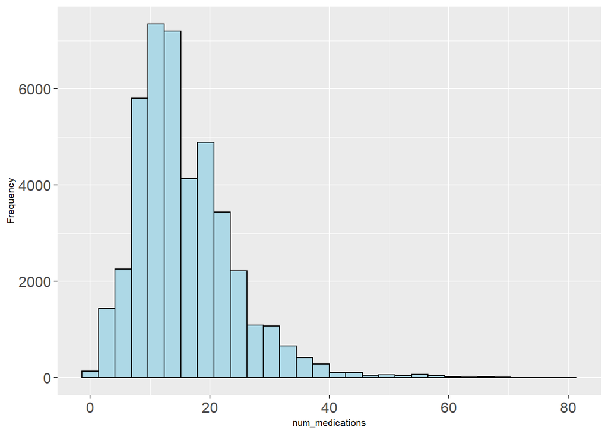

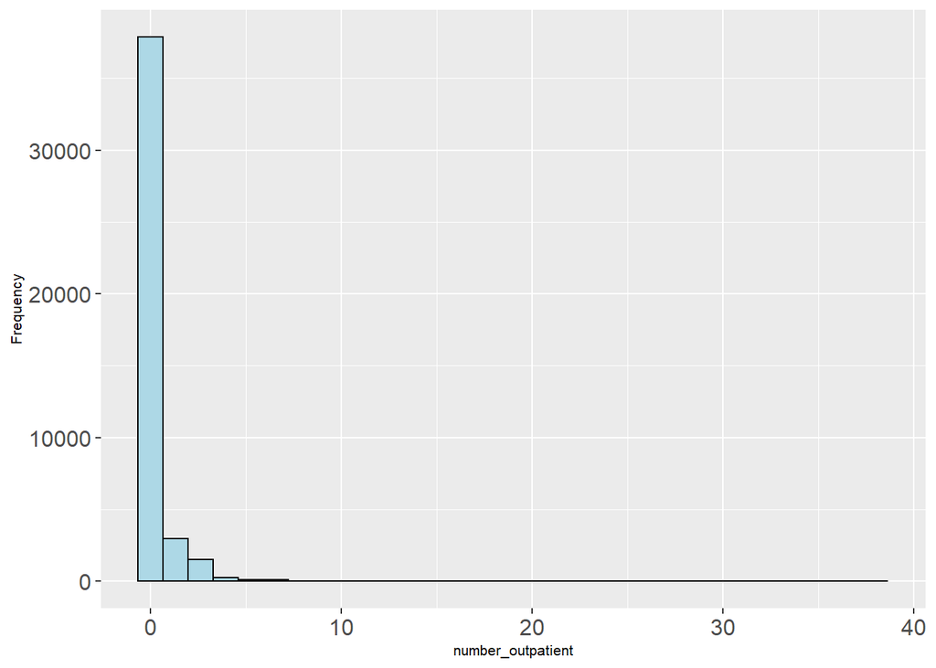

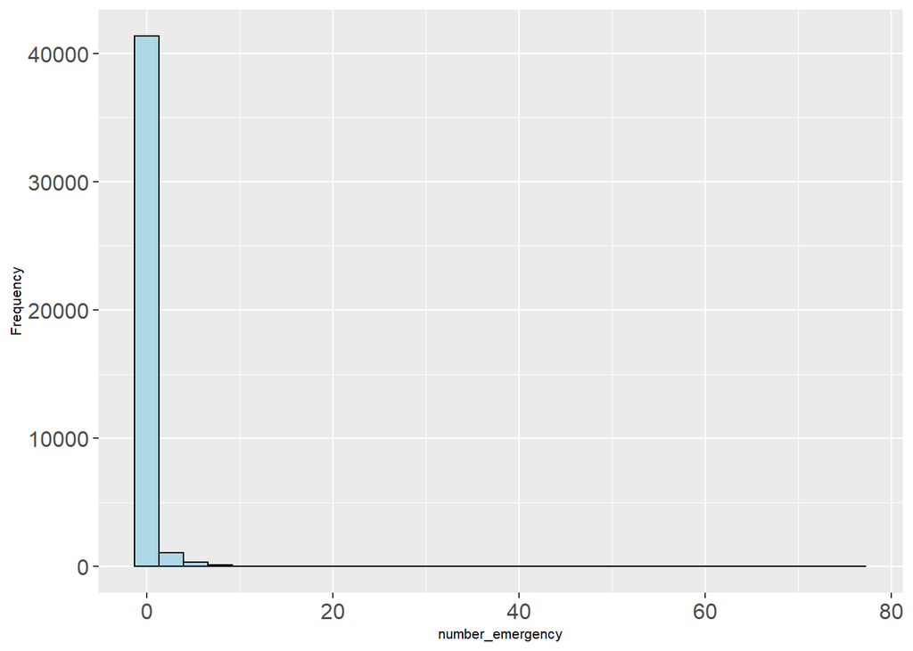

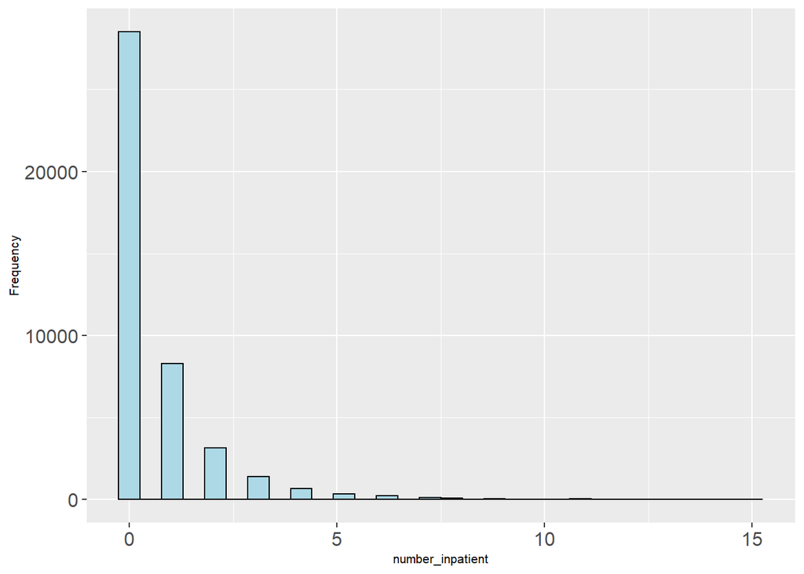

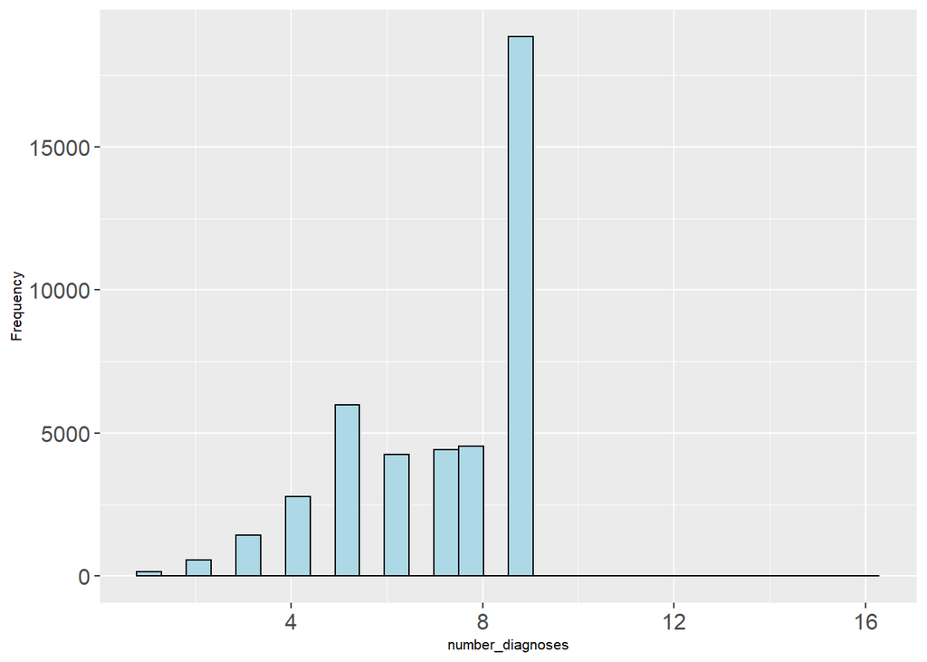

```r
hist_list <- list()
z <- 0
for (i in 1:ncol(df_diabetes)){
  if(is.numeric(df_diabetes[,i])){
    z <- z+1
    hist <- ggplot(data=df_diabetes,aes_string(names(df_diabetes)[i]))+
      geom_histogram(fill='lightblue',color='black')+
      labs(x=colnames(df_diabetes)[i],y= "Frequency")+
      theme(axis.text=element_text(size=12),
        axis.title=element_text(size=8))
    hist_list[[z]] <- hist
  }
}
hist_list
```

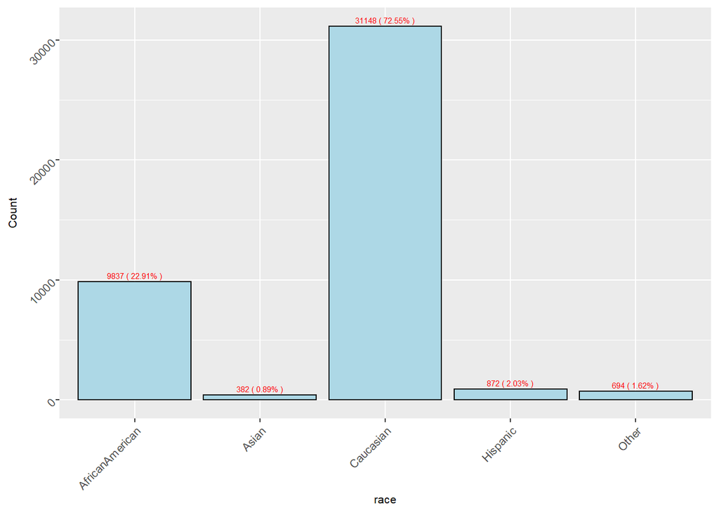

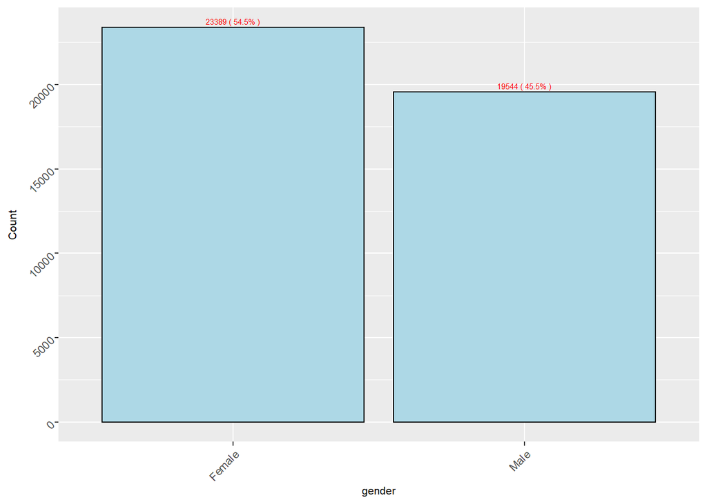

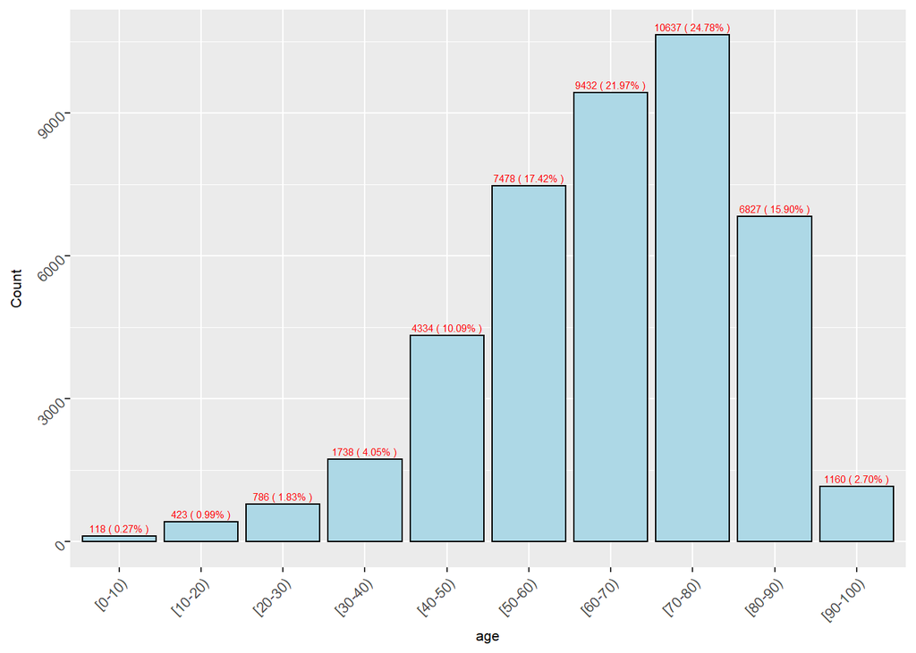

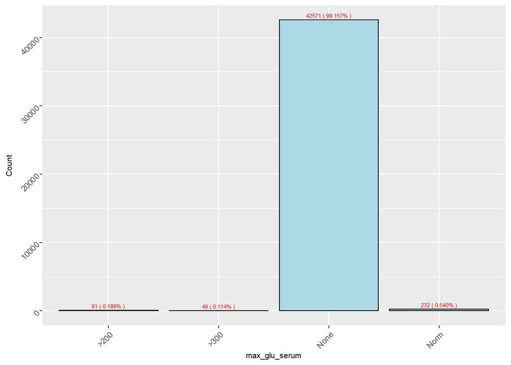

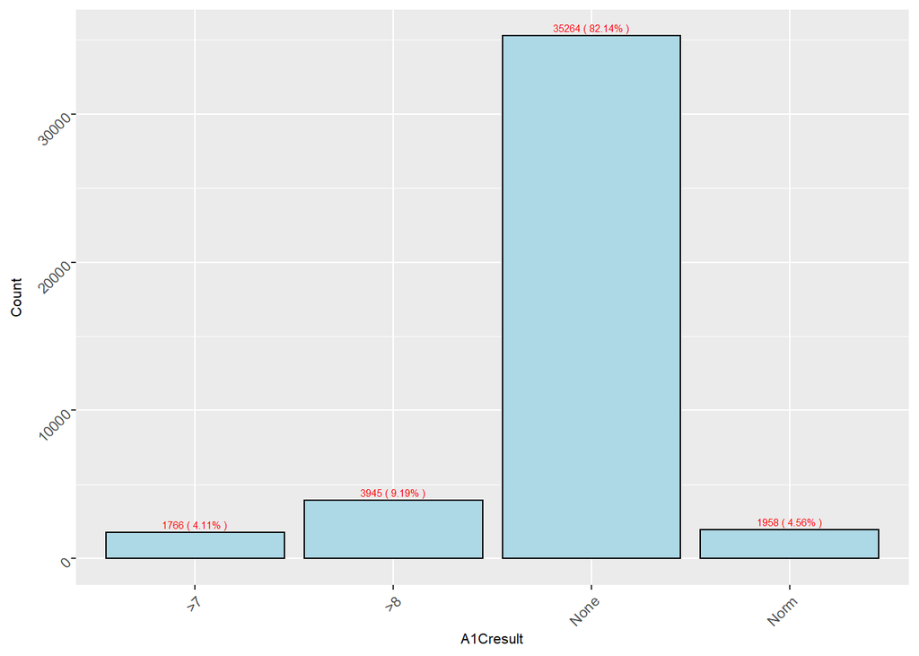

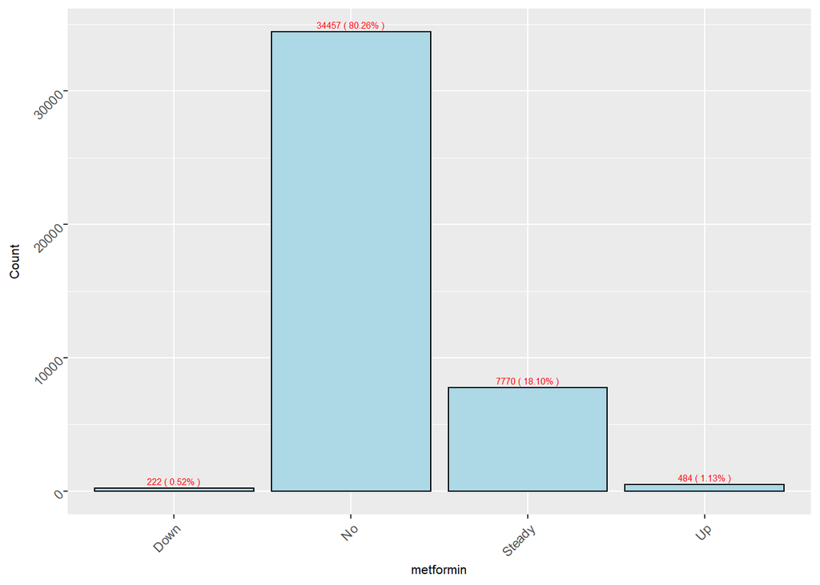

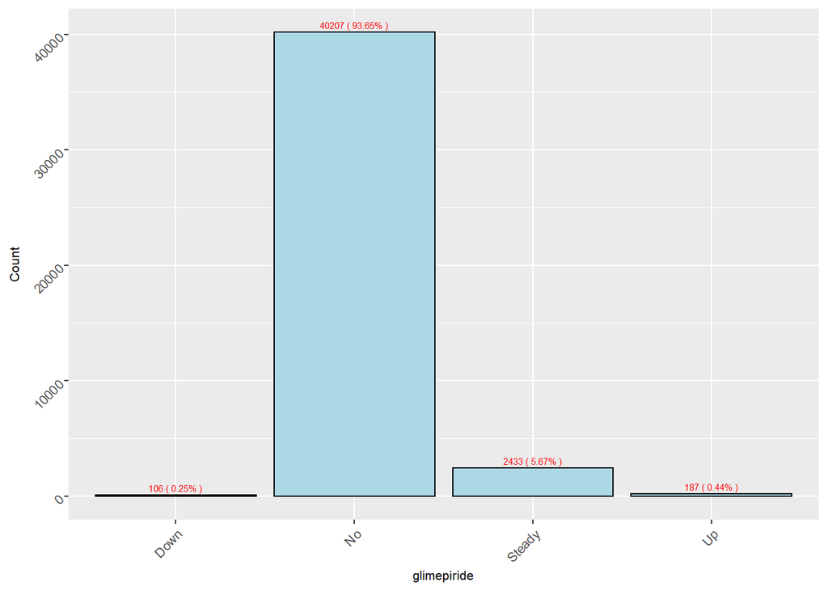

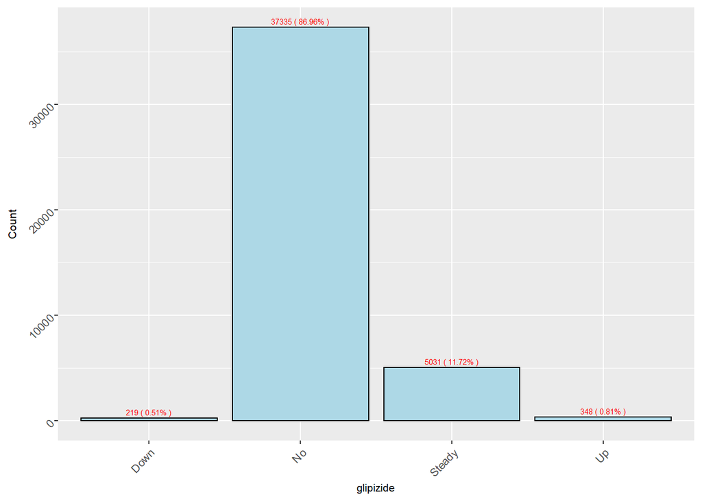

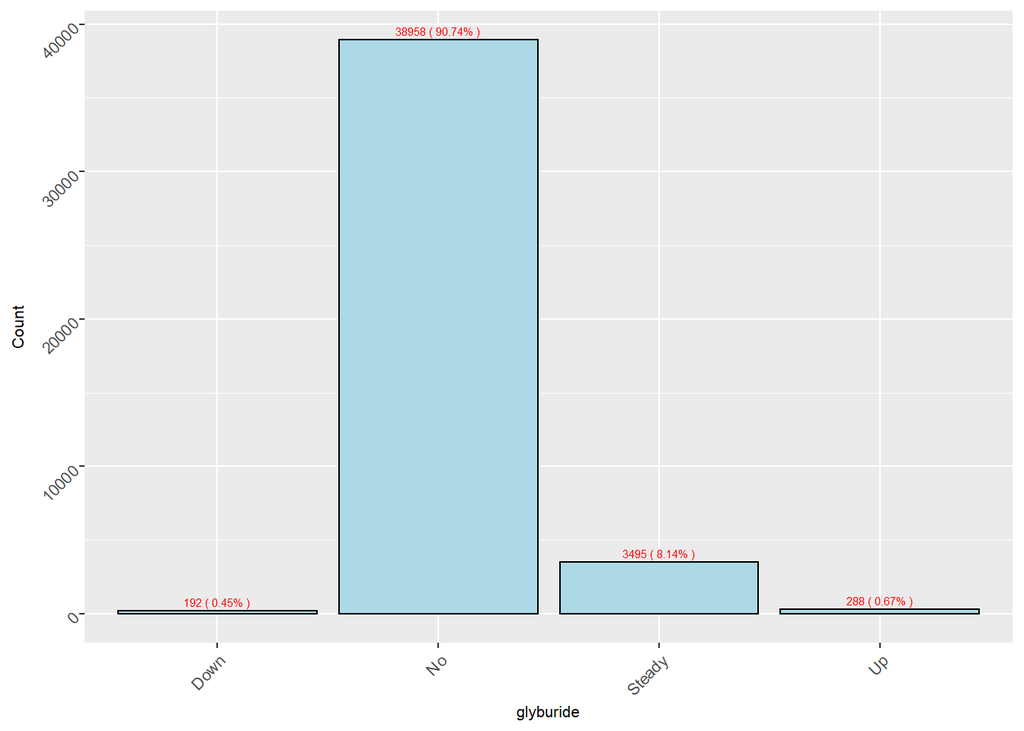

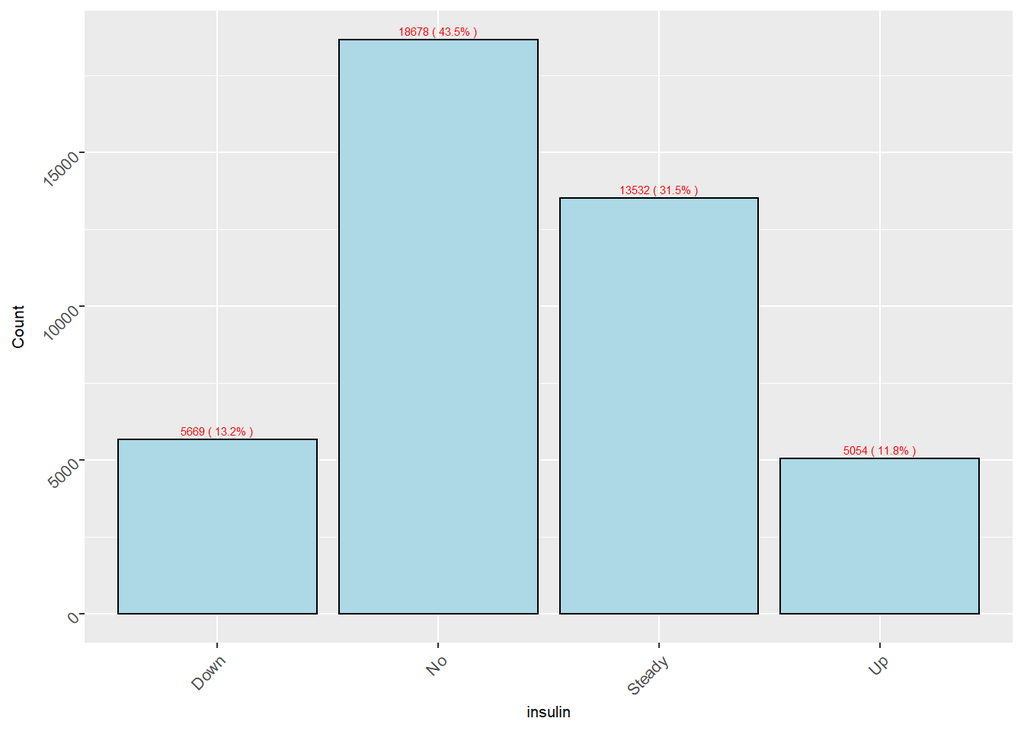

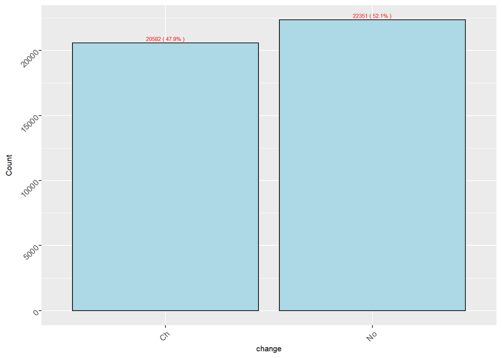

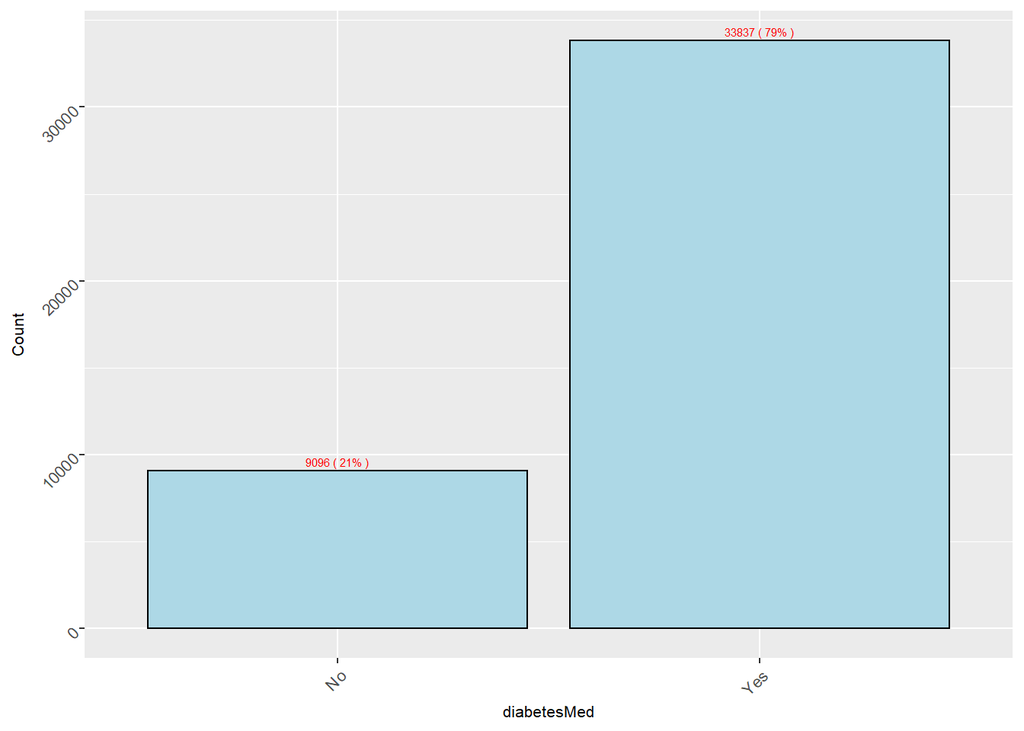

[19 more figures not shown]

```r
library(scales)
bar_list <- list()
z <- 0

for (i in 1:ncol(df_diabetes)){
  if(is.factor(df_diabetes[,i])){
    z <- z+1
    class <- df_diabetes %>%
     group_by((df_diabetes)[i]) %>%
     dplyr::summarise(number=n()) %>%
     mutate(percentage=percent(number/sum(number))) %>%
     mutate(pos = cumsum(number)- number/1.5) #Create a variable to indicate the position of labels
    bar <- ggplot(data=class,aes_string(x=colnames(class)[1],y=colnames(class)[2]))+
      geom_bar(fill='lightblue',color='black',stat = "identity")+
      labs(x=colnames(df_diabetes)[i],y= "Count")+
      geom_text(aes(label=paste(number,"(",percentage,")")),vjust=-0.5,size=2,color="red")+
      theme(axis.text=element_text(size=8,angle=45,hjust=1),axis.title=element_text(size=8))
    bar_list[[z]] <- bar
  }
}
bar_list
```

The grouped box plots below show that the time in hospital, number of lab procedures, number of medications, number of outpatient visits, number of emergency visits, number of inpatient visits and the number of diagnoses are all significantly higher in the readmitted group (p<0.05, t<0)

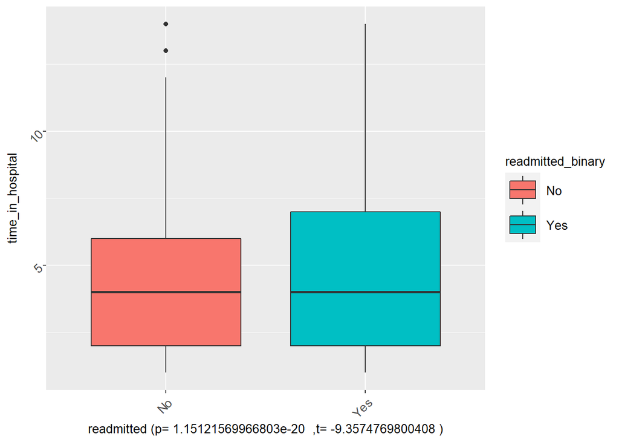

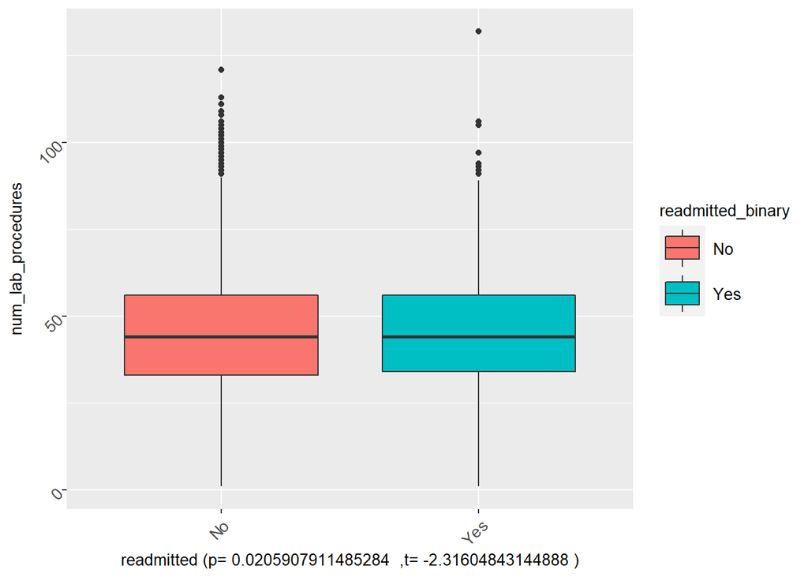

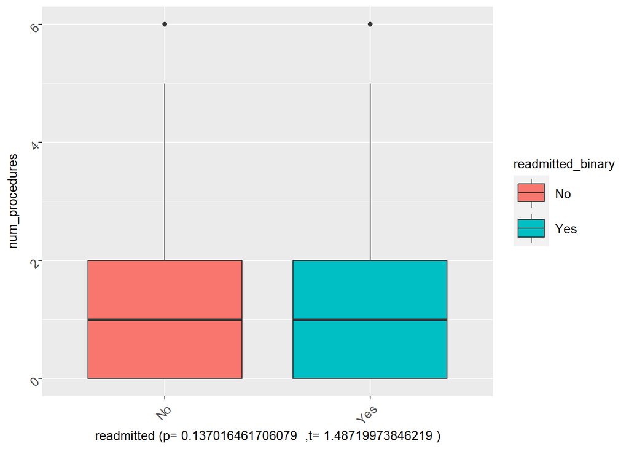

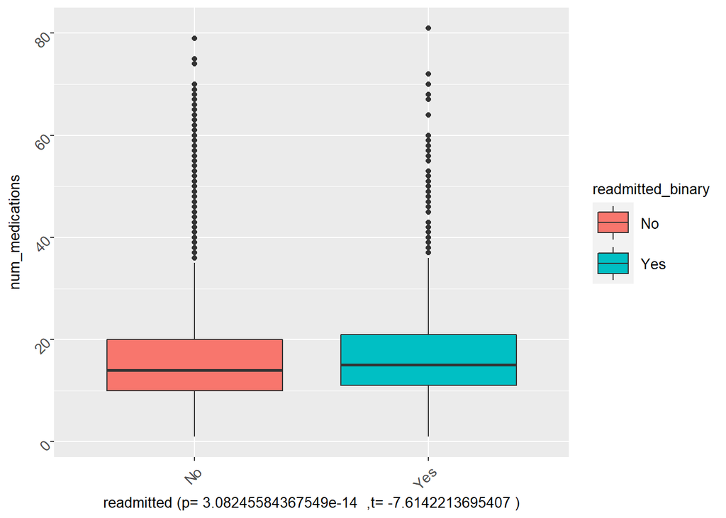

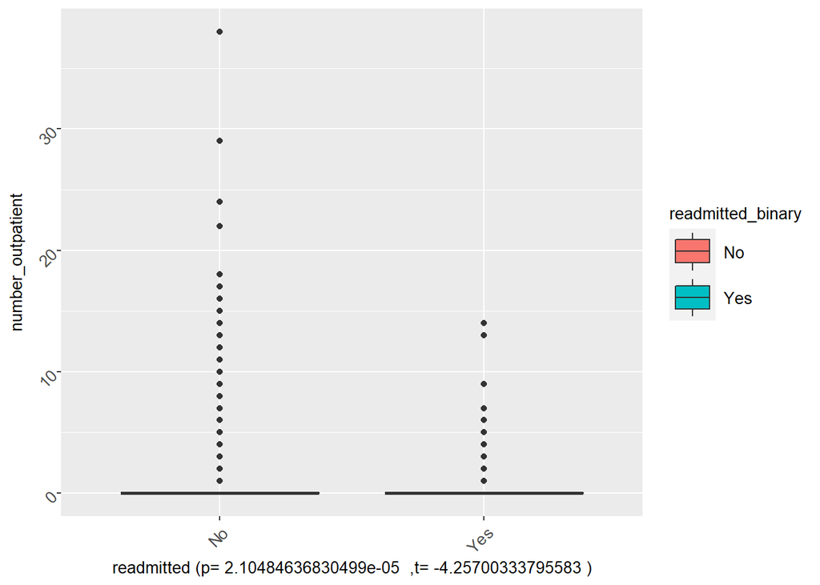

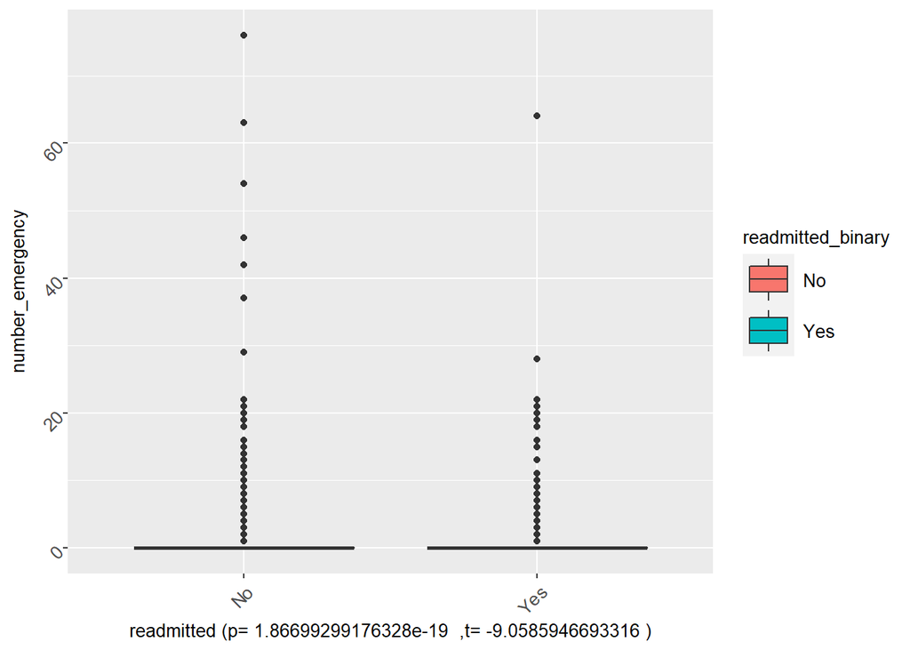

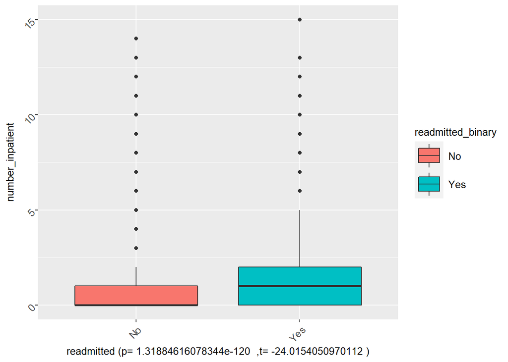

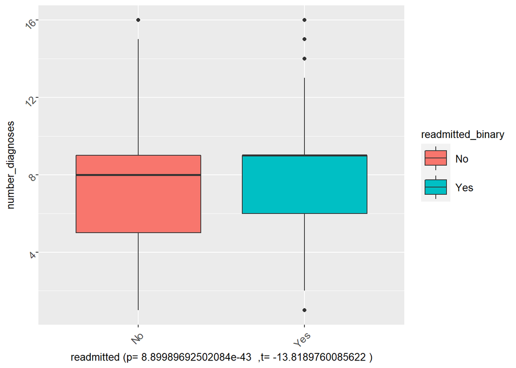

```r
var_list <- colnames(df_diabetes)
grouped_box_list <- list()
z <- 0
for (i in 1:ncol(df_diabetes)){
  if (is.numeric(df_diabetes[,i])){
    # add p value for the t test in the grouped chart
    t <- unname(t.test(df_diabetes[,i]~df_diabetes$readmitted_binary)[[1]])
    p <- t.test(df_diabetes[,i]~df_diabetes$readmitted_binary)$p.value
    ad_index=which(names(df_diabetes)=='readmitted_binary')
    z <- z+1
    grouped_box <- ggplot(data=df_diabetes,aes_string(x=var_list[ad_index],y=var_list[i],fill=var_list[ad_index]))+
      geom_boxplot()+
      theme(axis.text=element_text(size=10,angle=45,hjust=1),axis.title=element_text(size=10),legend.key.size=unit(1,"cm"),legend.title=element_text(size=10),legend.text=element_text(size=10))+xlab(paste("readmitted (p=",p," ,t=",t,")"))
    grouped_box_list[[z]] <- grouped_box
  }
}
grouped_box_list
```